# Risk Factor Analysis

## Outcome Variable

**Outcome Variable:** y_rate_haz

## Predictor Variables

**Intervention Variable:** predfeed3

**Adjustment Set:**

- arm
- sex
- month
- brthmon
- W_mage
- meducyrs
- feducyrs
- hhwealth_quart
- hfoodsec
- W_mhtcm
- vagbrth
- W_gagebrth
- W_birthwt
- W_birthlen
- W_nrooms
- W_nchldlt5
- W_parity
- impfloor
- impsan
- safeh20
- delta_W_mage
- delta_meducyrs
- delta_feducyrs
- delta_hhwealth_quart
- delta_hfoodsec
- delta_W_mhtcm
- delta_vagbrth
- delta_W_gagebrth
- delta_W_birthwt
- delta_W_birthlen
- delta_W_nrooms
- delta_W_nchldlt5
- delta_W_parity
- delta_impfloor
- delta_impsan
- delta_safeh20

## Stratifying Variables

The analysis was stratified on these variable(s):

- agecat
- studyid
- country

## Data Summary

| agecat | studyid | country | predfeed3 | n_cell | n |
| --- | --- | --- | --- | --- | --- |
| 0-3 months | ki0047075b-MAL-ED | BANGLADESH | 0 | 35 | 239 |
| 0-3 months | ki0047075b-MAL-ED | BANGLADESH | 1 | 204 | 239 |
| 0-3 months | ki0047075b-MAL-ED | BRAZIL | 0 | 80 | 180 |
| 0-3 months | ki0047075b-MAL-ED | BRAZIL | 1 | 100 | 180 |
| 0-3 months | ki0047075b-MAL-ED | INDIA | 0 | 46 | 199 |
| 0-3 months | ki0047075b-MAL-ED | INDIA | 1 | 153 | 199 |
| 0-3 months | ki0047075b-MAL-ED | NEPAL | 0 | 73 | 175 |
| 0-3 months | ki0047075b-MAL-ED | NEPAL | 1 | 102 | 175 |
| 0-3 months | ki0047075b-MAL-ED | PERU | 0 | 89 | 268 |
| 0-3 months | ki0047075b-MAL-ED | PERU | 1 | 179 | 268 |
| 0-3 months | ki0047075b-MAL-ED | SOUTH AFRICA | 0 | 140 | 226 |
| 0-3 months | ki0047075b-MAL-ED | SOUTH AFRICA | 1 | 86 | 226 |
| 0-3 months | ki0047075b-MAL-ED | TANZANIA, UNITED REPUBLIC OF | 0 | 145 | 224 |
| 0-3 months | ki0047075b-MAL-ED | TANZANIA, UNITED REPUBLIC OF | 1 | 79 | 224 |
| 0-3 months | ki1000109-EE | PAKISTAN | 0 | 32 | 592 |
| 0-3 months | ki1000109-EE | PAKISTAN | 1 | 560 | 592 |
| 0-3 months | kiGH5241-JiVitA-3 | BANGLADESH | 0 | 4246 | 39314 |
| 0-3 months | kiGH5241-JiVitA-3 | BANGLADESH | 1 | 35068 | 39314 |
| 0-3 months | kiGH5241-JiVitA-4 | BANGLADESH | 0 | 20 | 242 |
| 0-3 months | kiGH5241-JiVitA-4 | BANGLADESH | 1 | 222 | 242 |
| 3-6 months | ki0047075b-MAL-ED | BANGLADESH | 0 | 33 | 227 |
| 3-6 months | ki0047075b-MAL-ED | BANGLADESH | 1 | 194 | 227 |
| 3-6 months | ki0047075b-MAL-ED | BRAZIL | 0 | 92 | 208 |
| 3-6 months | ki0047075b-MAL-ED | BRAZIL | 1 | 116 | 208 |
| 3-6 months | ki0047075b-MAL-ED | INDIA | 0 | 53 | 229 |
| 3-6 months | ki0047075b-MAL-ED | INDIA | 1 | 176 | 229 |
| 3-6 months | ki0047075b-MAL-ED | NEPAL | 0 | 101 | 232 |
| 3-6 months | ki0047075b-MAL-ED | NEPAL | 1 | 131 | 232 |
| 3-6 months | ki0047075b-MAL-ED | PERU | 0 | 84 | 265 |
| 3-6 months | ki0047075b-MAL-ED | PERU | 1 | 181 | 265 |

[output cut: 54 more lines]

The following strata were considered:

- agecat: 0-3 months, studyid: ki0047075b-MAL-ED, country: BANGLADESH
- agecat: 0-3 months, studyid: ki0047075b-MAL-ED, country: BRAZIL
- agecat: 0-3 months, studyid: ki0047075b-MAL-ED, country: INDIA
- agecat: 0-3 months, studyid: ki0047075b-MAL-ED, country: NEPAL
- agecat: 0-3 months, studyid: ki0047075b-MAL-ED, country: PERU
- agecat: 0-3 months, studyid: ki0047075b-MAL-ED, country: SOUTH AFRICA
- agecat: 0-3 months, studyid: ki0047075b-MAL-ED, country: TANZANIA, UNITED REPUBLIC OF
- agecat: 0-3 months, studyid: ki1000109-EE, country: PAKISTAN
- agecat: 0-3 months, studyid: kiGH5241-JiVitA-3, country: BANGLADESH
- agecat: 0-3 months, studyid: kiGH5241-JiVitA-4, country: BANGLADESH
- agecat: 12-24 months, studyid: ki0047075b-MAL-ED, country: BANGLADESH
- agecat: 12-24 months, studyid: ki0047075b-MAL-ED, country: BRAZIL
- agecat: 12-24 months, studyid: ki0047075b-MAL-ED, country: INDIA
- agecat: 12-24 months, studyid: ki0047075b-MAL-ED, country: NEPAL
- agecat: 12-24 months, studyid: ki0047075b-MAL-ED, country: PERU
- agecat: 12-24 months, studyid: ki0047075b-MAL-ED, country: SOUTH AFRICA
- agecat: 12-24 months, studyid: ki0047075b-MAL-ED, country: TANZANIA, UNITED REPUBLIC OF
- agecat: 12-24 months, studyid: ki1113344-GMS-Nepal, country: NEPAL
- agecat: 12-24 months, studyid: kiGH5241-JiVitA-3, country: BANGLADESH
- agecat: 12-24 months, studyid: kiGH5241-JiVitA-4, country: BANGLADESH
- agecat: 3-6 months, studyid: ki0047075b-MAL-ED, country: BANGLADESH
- agecat: 3-6 months, studyid: ki0047075b-MAL-ED, country: BRAZIL
- agecat: 3-6 months, studyid: ki0047075b-MAL-ED, country: INDIA
- agecat: 3-6 months, studyid: ki0047075b-MAL-ED, country: NEPAL
- agecat: 3-6 months, studyid: ki0047075b-MAL-ED, country: PERU
- agecat: 3-6 months, studyid: ki0047075b-MAL-ED, country: SOUTH AFRICA
- agecat: 3-6 months, studyid: ki0047075b-MAL-ED, country: TANZANIA, UNITED REPUBLIC OF
- agecat: 3-6 months, studyid: ki1000109-EE, country: PAKISTAN
- agecat: 3-6 months, studyid: ki1113344-GMS-Nepal, country: NEPAL
- agecat: 3-6 months, studyid: kiGH5241-JiVitA-3, country: BANGLADESH
- agecat: 3-6 months, studyid: kiGH5241-JiVitA-4, country: BANGLADESH
- agecat: 6-12 months, studyid: ki0047075b-MAL-ED, country: BANGLADESH
- agecat: 6-12 months, studyid: ki0047075b-MAL-ED, country: BRAZIL
- agecat: 6-12 months, studyid: ki0047075b-MAL-ED, country: INDIA
- agecat: 6-12 months, studyid: ki0047075b-MAL-ED, country: NEPAL
- agecat: 6-12 months, studyid: ki0047075b-MAL-ED, country: PERU
- agecat: 6-12 months, studyid: ki0047075b-MAL-ED, country: SOUTH AFRICA
- agecat: 6-12 months, studyid: ki0047075b-MAL-ED, country: TANZANIA, UNITED REPUBLIC OF
- agecat: 6-12 months, studyid: ki1000109-EE, country: PAKISTAN
- agecat: 6-12 months, studyid: ki1113344-GMS-Nepal, country: NEPAL
- agecat: 6-12 months, studyid: kiGH5241-JiVitA-3, country: BANGLADESH
- agecat: 6-12 months, studyid: kiGH5241-JiVitA-4, country: BANGLADESH

### Dropped Strata

Some strata were dropped due to rare outcomes:

- agecat: 3-6 months, studyid: kiGH5241-JiVitA-4, country: BANGLADESH
- agecat: 6-12 months, studyid: ki1000109-EE, country: PAKISTAN
- agecat: 6-12 months, studyid: kiGH5241-JiVitA-4, country: BANGLADESH

## Methods Detail

We’re interested in the causal parameters $E[Y_a]$ for all values of $a \in \mathcal{A}$. These parameters represent the mean outcome if, possibly contrary to fact, we intervened to set all units to have $A=a$. Under the randomization and positivity assumptions, these are identified by the statistical parameters $\psi_a=E_W[E_{Y|A,W}(Y|A=a,W)]$. In addition, we’re interested in the mean of $Y$, $E[Y]$ under no intervention (the observed mean). We will estimate these parameters by using SuperLearner to fit the relevant likelihood factors – $E_{Y|A,W}(Y|A=a,W)$ and $p(A=a|W)$, and then updating our likelihood fit using a joint TMLE.

For unadjusted analyses ($W=\{\}$), initial likelihoods were estimated using Lrnr_glm to estimate the simple $E(Y|A)$ and Lrnr_mean to estimate $p(A)$. For adjusted analyses, a small library containing Lrnr_glmnet, Lrnr_xgboost, and Lrnr_mean was used.

Having estimated these parameters, we will then use the delta method to estimate relative risks and attributable risks relative to a prespecified baseline level of $A$.

# Results Detail

## Results Plots

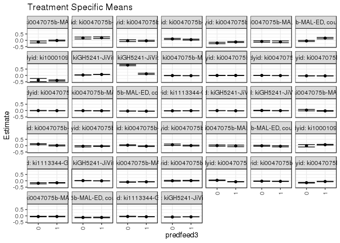

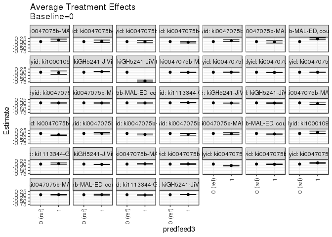

## Results Table

### Parameter: TSM

| agecat | studyid | country | intervention_level | baseline_level | estimate | ci_lower | ci_upper |
| --- | --- | --- | --- | --- | --- | --- | --- |
| 0-3 months | ki0047075b-MAL-ED | BANGLADESH | 0 | NA | -0.1283741 | -0.2038362 | -0.0529119 |
| 0-3 months | ki0047075b-MAL-ED | BANGLADESH | 1 | NA | -0.0154722 | -0.0507163 | 0.0197718 |
| 0-3 months | ki0047075b-MAL-ED | BRAZIL | 0 | NA | 0.1816206 | 0.1069382 | 0.2563030 |
| 0-3 months | ki0047075b-MAL-ED | BRAZIL | 1 | NA | 0.2018499 | 0.1330364 | 0.2706635 |
| 0-3 months | ki0047075b-MAL-ED | INDIA | 0 | NA | -0.0295851 | -0.1018372 | 0.0426669 |
| 0-3 months | ki0047075b-MAL-ED | INDIA | 1 | NA | -0.0363961 | -0.0791494 | 0.0063571 |
| 0-3 months | ki0047075b-MAL-ED | NEPAL | 0 | NA | 0.1093176 | 0.0634619 | 0.1551733 |
| 0-3 months | ki0047075b-MAL-ED | NEPAL | 1 | NA | 0.0526396 | 0.0130657 | 0.0922135 |
| 0-3 months | ki0047075b-MAL-ED | PERU | 0 | NA | -0.2102254 | -0.2674451 | -0.1530056 |
| 0-3 months | ki0047075b-MAL-ED | PERU | 1 | NA | -0.1316153 | -0.1674857 | -0.0957450 |
| 0-3 months | ki0047075b-MAL-ED | SOUTH AFRICA | 0 | NA | -0.0908976 | -0.1473028 | -0.0344924 |
| 0-3 months | ki0047075b-MAL-ED | SOUTH AFRICA | 1 | NA | -0.1171212 | -0.1888264 | -0.0454160 |
| 0-3 months | ki0047075b-MAL-ED | TANZANIA, UNITED REPUBLIC OF | 0 | NA | -0.0483786 | -0.0946605 | -0.0020967 |
| 0-3 months | ki0047075b-MAL-ED | TANZANIA, UNITED REPUBLIC OF | 1 | NA | 0.1700679 | 0.1146163 | 0.2255194 |
| 0-3 months | ki1000109-EE | PAKISTAN | 0 | NA | -0.3641828 | -0.4914754 | -0.2368903 |
| 0-3 months | ki1000109-EE | PAKISTAN | 1 | NA | -0.3962610 | -0.4408274 | -0.3516945 |
| 0-3 months | kiGH5241-JiVitA-3 | BANGLADESH | 0 | NA | 0.0347511 | 0.0241718 | 0.0453305 |
| 0-3 months | kiGH5241-JiVitA-3 | BANGLADESH | 1 | NA | 0.0773262 | 0.0722335 | 0.0824188 |
| 0-3 months | kiGH5241-JiVitA-4 | BANGLADESH | 0 | NA | 0.8151961 | 0.7671065 | 0.8632857 |
| 0-3 months | kiGH5241-JiVitA-4 | BANGLADESH | 1 | NA | 0.1302837 | 0.0832171 | 0.1773504 |
| 3-6 months | ki0047075b-MAL-ED | BANGLADESH | 0 | NA | 0.0308584 | -0.0241064 | 0.0858233 |
| 3-6 months | ki0047075b-MAL-ED | BANGLADESH | 1 | NA | -0.0288017 | -0.0538159 | -0.0037875 |
| 3-6 months | ki0047075b-MAL-ED | BRAZIL | 0 | NA | 0.1177994 | 0.0754838 | 0.1601150 |
| 3-6 months | ki0047075b-MAL-ED | BRAZIL | 1 | NA | 0.0151884 | -0.0243178 | 0.0546945 |
| 3-6 months | ki0047075b-MAL-ED | INDIA | 0 | NA | -0.0486519 | -0.0998585 | 0.0025547 |
| 3-6 months | ki0047075b-MAL-ED | INDIA | 1 | NA | -0.0383614 | -0.0674125 | -0.0093103 |
| 3-6 months | ki0047075b-MAL-ED | NEPAL | 0 | NA | 0.0364959 | 0.0031546 | 0.0698372 |
| 3-6 months | ki0047075b-MAL-ED | NEPAL | 1 | NA | -0.0415056 | -0.0710538 | -0.0119574 |
| 3-6 months | ki0047075b-MAL-ED | PERU | 0 | NA | 0.0724243 | 0.0156474 | 0.1292013 |
| 3-6 months | ki0047075b-MAL-ED | PERU | 1 | NA | 0.0078787 | -0.0281302 | 0.0438876 |
| 3-6 months | ki0047075b-MAL-ED | SOUTH AFRICA | 0 | NA | 0.0059063 | -0.0417337 | 0.0535464 |
| 3-6 months | ki0047075b-MAL-ED | SOUTH AFRICA | 1 | NA | -0.0170997 | -0.0809397 | 0.0467403 |
| 3-6 months | ki0047075b-MAL-ED | TANZANIA, UNITED REPUBLIC OF | 0 | NA | -0.0084384 | -0.0480631 | 0.0311864 |
| 3-6 months | ki0047075b-MAL-ED | TANZANIA, UNITED REPUBLIC OF | 1 | NA | -0.0462648 | -0.0942036 | 0.0016739 |
| 3-6 months | ki1000109-EE | PAKISTAN | 0 | NA | -0.0096865 | -0.1059733 | 0.0866004 |
| 3-6 months | ki1000109-EE | PAKISTAN | 1 | NA | 0.0747449 | 0.0458090 | 0.1036808 |
| 3-6 months | ki1113344-GMS-Nepal | NEPAL | 0 | NA | -0.1974501 | -0.2451402 | -0.1497600 |
| 3-6 months | ki1113344-GMS-Nepal | NEPAL | 1 | NA | -0.1594054 | -0.1804189 | -0.1383920 |
| 3-6 months | kiGH5241-JiVitA-3 | BANGLADESH | 0 | NA | 0.0113407 | 0.0000556 | 0.0226258 |
| 3-6 months | kiGH5241-JiVitA-3 | BANGLADESH | 1 | NA | -0.0075111 | -0.0125116 | -0.0025106 |
| 6-12 months | ki0047075b-MAL-ED | BANGLADESH | 0 | NA | -0.1001525 | -0.1179572 | -0.0823477 |
| 6-12 months | ki0047075b-MAL-ED | BANGLADESH | 1 | NA | -0.0835879 | -0.0942954 | -0.0728804 |
| 6-12 months | ki0047075b-MAL-ED | BRAZIL | 0 | NA | 0.0007871 | -0.0323705 | 0.0339447 |
| 6-12 months | ki0047075b-MAL-ED | BRAZIL | 1 | NA | 0.0109762 | -0.0122175 | 0.0341699 |
| 6-12 months | ki0047075b-MAL-ED | INDIA | 0 | NA | 0.0368604 | 0.0119297 | 0.0617912 |
| 6-12 months | ki0047075b-MAL-ED | INDIA | 1 | NA | -0.0780125 | -0.0913080 | -0.0647171 |
| 6-12 months | ki0047075b-MAL-ED | NEPAL | 0 | NA | -0.0313842 | -0.0474827 | -0.0152858 |
| 6-12 months | ki0047075b-MAL-ED | NEPAL | 1 | NA | -0.0453935 | -0.0586491 | -0.0321380 |
| 6-12 months | ki0047075b-MAL-ED | PERU | 0 | NA | -0.1512813 | -0.1776107 | -0.1249520 |
| 6-12 months | ki0047075b-MAL-ED | PERU | 1 | NA | -0.0566949 | -0.0734909 | -0.0398989 |
| 6-12 months | ki0047075b-MAL-ED | SOUTH AFRICA | 0 | NA | -0.0524931 | -0.0724310 | -0.0325552 |
| 6-12 months | ki0047075b-MAL-ED | SOUTH AFRICA | 1 | NA | -0.0498920 | -0.0731654 | -0.0266187 |
| 6-12 months | ki0047075b-MAL-ED | TANZANIA, UNITED REPUBLIC OF | 0 | NA | -0.1255001 | -0.1448941 | -0.1061061 |
| 6-12 months | ki0047075b-MAL-ED | TANZANIA, UNITED REPUBLIC OF | 1 | NA | -0.1232083 | -0.1509663 | -0.0954503 |
| 6-12 months | ki1113344-GMS-Nepal | NEPAL | 0 | NA | -0.0468412 | -0.0667098 | -0.0269727 |
| 6-12 months | ki1113344-GMS-Nepal | NEPAL | 1 | NA | -0.0672179 | -0.0775306 | -0.0569051 |
| 6-12 months | kiGH5241-JiVitA-3 | BANGLADESH | 0 | NA | -0.0857739 | -0.0924371 | -0.0791106 |
| 6-12 months | kiGH5241-JiVitA-3 | BANGLADESH | 1 | NA | -0.0755014 | -0.0784287 | -0.0725742 |
| 12-24 months | ki0047075b-MAL-ED | BANGLADESH | 0 | NA | -0.0084363 | -0.0219706 | 0.0050981 |
| 12-24 months | ki0047075b-MAL-ED | BANGLADESH | 1 | NA | -0.0193612 | -0.0251607 | -0.0135617 |
| 12-24 months | ki0047075b-MAL-ED | BRAZIL | 0 | NA | -0.0018781 | -0.0144724 | 0.0107162 |
| 12-24 months | ki0047075b-MAL-ED | BRAZIL | 1 | NA | -0.0006083 | -0.0132999 | 0.0120832 |
| 12-24 months | ki0047075b-MAL-ED | INDIA | 0 | NA | 0.0018427 | -0.0064700 | 0.0101554 |
| 12-24 months | ki0047075b-MAL-ED | INDIA | 1 | NA | -0.0134631 | -0.0195913 | -0.0073349 |
| 12-24 months | ki0047075b-MAL-ED | NEPAL | 0 | NA | -0.0323636 | -0.0392044 | -0.0255227 |
| 12-24 months | ki0047075b-MAL-ED | NEPAL | 1 | NA | -0.0346066 | -0.0411792 | -0.0280340 |
| 12-24 months | ki0047075b-MAL-ED | PERU | 0 | NA | -0.0047780 | -0.0179340 | 0.0083780 |
| 12-24 months | ki0047075b-MAL-ED | PERU | 1 | NA | -0.0109486 | -0.0187977 | -0.0030994 |
| 12-24 months | ki0047075b-MAL-ED | SOUTH AFRICA | 0 | NA | -0.0125416 | -0.0220694 | -0.0030138 |
| 12-24 months | ki0047075b-MAL-ED | SOUTH AFRICA | 1 | NA | -0.0205203 | -0.0332221 | -0.0078185 |
| 12-24 months | ki0047075b-MAL-ED | TANZANIA, UNITED REPUBLIC OF | 0 | NA | -0.0410148 | -0.0501706 | -0.0318590 |
| 12-24 months | ki0047075b-MAL-ED | TANZANIA, UNITED REPUBLIC OF | 1 | NA | -0.0490790 | -0.0584754 | -0.0396827 |
| 12-24 months | ki1113344-GMS-Nepal | NEPAL | 0 | NA | -0.0231577 | -0.0349066 | -0.0114087 |
| 12-24 months | ki1113344-GMS-Nepal | NEPAL | 1 | NA | -0.0144326 | -0.0205872 | -0.0082780 |
| 12-24 months | kiGH5241-JiVitA-3 | BANGLADESH | 0 | NA | -0.0074773 | -0.0109722 | -0.0039824 |
| 12-24 months | kiGH5241-JiVitA-3 | BANGLADESH | 1 | NA | -0.0199804 | -0.0218983 | -0.0180625 |
| 12-24 months | kiGH5241-JiVitA-4 | BANGLADESH | 0 | NA | 0.0034714 | -0.0171669 | 0.0241097 |
| 12-24 months | kiGH5241-JiVitA-4 | BANGLADESH | 1 | NA | -0.0099925 | -0.0183987 | -0.0015862 |

### Parameter: E(Y)

| agecat | studyid | country | intervention_level | baseline_level | estimate | ci_lower | ci_upper |
| --- | --- | --- | --- | --- | --- | --- | --- |
| 0-3 months | ki0047075b-MAL-ED | BANGLADESH | NA | NA | -0.0320043 | -0.0644701 | 0.0004615 |
| 0-3 months | ki0047075b-MAL-ED | BRAZIL | NA | NA | 0.1928587 | 0.1409027 | 0.2448147 |
| 0-3 months | ki0047075b-MAL-ED | INDIA | NA | NA | -0.0255097 | -0.0638598 | 0.0128403 |
| 0-3 months | ki0047075b-MAL-ED | NEPAL | NA | NA | 0.0746202 | 0.0395269 | 0.1097135 |
| 0-3 months | ki0047075b-MAL-ED | PERU | NA | NA | -0.1578735 | -0.1906434 | -0.1251037 |
| 0-3 months | ki0047075b-MAL-ED | SOUTH AFRICA | NA | NA | -0.1008775 | -0.1453661 | -0.0563889 |
| 0-3 months | ki0047075b-MAL-ED | TANZANIA, UNITED REPUBLIC OF | NA | NA | -0.0485757 | -0.0876660 | -0.0094853 |
| 0-3 months | ki1000109-EE | PAKISTAN | NA | NA | -0.3945273 | -0.4372606 | -0.3517940 |
| 0-3 months | kiGH5241-JiVitA-3 | BANGLADESH | NA | NA | 0.0707032 | 0.0657297 | 0.0756767 |
| 0-3 months | kiGH5241-JiVitA-4 | BANGLADESH | NA | NA | 0.1109539 | 0.0661941 | 0.1557138 |
| 3-6 months | ki0047075b-MAL-ED | BANGLADESH | NA | NA | -0.0200415 | -0.0431395 | 0.0030565 |
| 3-6 months | ki0047075b-MAL-ED | BRAZIL | NA | NA | 0.0604904 | 0.0239698 | 0.0970111 |
| 3-6 months | ki0047075b-MAL-ED | INDIA | NA | NA | -0.0401251 | -0.0685271 | -0.0117231 |
| 3-6 months | ki0047075b-MAL-ED | NEPAL | NA | NA | -0.0225157 | -0.0491401 | 0.0041087 |
| 3-6 months | ki0047075b-MAL-ED | PERU | NA | NA | 0.0283266 | -0.0028926 | 0.0595459 |
| 3-6 months | ki0047075b-MAL-ED | SOUTH AFRICA | NA | NA | -0.0024150 | -0.0406234 | 0.0357934 |
| 3-6 months | ki0047075b-MAL-ED | TANZANIA, UNITED REPUBLIC OF | NA | NA | -0.0727901 | -0.1056963 | -0.0398840 |
| 3-6 months | ki1000109-EE | PAKISTAN | NA | NA | 0.0708495 | 0.0425982 | 0.0991009 |
| 3-6 months | ki1113344-GMS-Nepal | NEPAL | NA | NA | -0.1660455 | -0.1856196 | -0.1464714 |
| 3-6 months | kiGH5241-JiVitA-3 | BANGLADESH | NA | NA | -0.0042530 | -0.0091354 | 0.0006295 |
| 6-12 months | ki0047075b-MAL-ED | BANGLADESH | NA | NA | -0.0807371 | -0.0912604 | -0.0702138 |
| 6-12 months | ki0047075b-MAL-ED | BRAZIL | NA | NA | 0.0065644 | -0.0129183 | 0.0260472 |
| 6-12 months | ki0047075b-MAL-ED | INDIA | NA | NA | -0.0777727 | -0.0900154 | -0.0655300 |
| 6-12 months | ki0047075b-MAL-ED | NEPAL | NA | NA | -0.0486002 | -0.0592412 | -0.0379593 |
| 6-12 months | ki0047075b-MAL-ED | PERU | NA | NA | -0.0374212 | -0.0515266 | -0.0233158 |
| 6-12 months | ki0047075b-MAL-ED | SOUTH AFRICA | NA | NA | -0.0517337 | -0.0693851 | -0.0340823 |
| 6-12 months | ki0047075b-MAL-ED | TANZANIA, UNITED REPUBLIC OF | NA | NA | -0.1246447 | -0.1406180 | -0.1086713 |
| 6-12 months | ki1113344-GMS-Nepal | NEPAL | NA | NA | -0.0638477 | -0.0730913 | -0.0546041 |
| 6-12 months | kiGH5241-JiVitA-3 | BANGLADESH | NA | NA | -0.0753247 | -0.0782379 | -0.0724114 |
| 12-24 months | ki0047075b-MAL-ED | BANGLADESH | NA | NA | -0.0181403 | -0.0236170 | -0.0126636 |
| 12-24 months | ki0047075b-MAL-ED | BRAZIL | NA | NA | -0.0013016 | -0.0119070 | 0.0093038 |
| 12-24 months | ki0047075b-MAL-ED | INDIA | NA | NA | -0.0097570 | -0.0149006 | -0.0046135 |
| 12-24 months | ki0047075b-MAL-ED | NEPAL | NA | NA | -0.0295235 | -0.0345942 | -0.0244528 |
| 12-24 months | ki0047075b-MAL-ED | PERU | NA | NA | -0.0090124 | -0.0160498 | -0.0019751 |
| 12-24 months | ki0047075b-MAL-ED | SOUTH AFRICA | NA | NA | -0.0153199 | -0.0229604 | -0.0076795 |
| 12-24 months | ki0047075b-MAL-ED | TANZANIA, UNITED REPUBLIC OF | NA | NA | -0.0396040 | -0.0475364 | -0.0316716 |
| 12-24 months | ki1113344-GMS-Nepal | NEPAL | NA | NA | -0.0158588 | -0.0213657 | -0.0103518 |
| 12-24 months | kiGH5241-JiVitA-3 | BANGLADESH | NA | NA | -0.0189244 | -0.0207907 | -0.0170581 |
| 12-24 months | kiGH5241-JiVitA-4 | BANGLADESH | NA | NA | -0.0089754 | -0.0170317 | -0.0009191 |

### Parameter: ATE

| agecat | studyid | country | intervention_level | baseline_level | estimate | ci_lower | ci_upper |
| --- | --- | --- | --- | --- | --- | --- | --- |
| 0-3 months | ki0047075b-MAL-ED | BANGLADESH | 0 | 0 | 0.0000000 | 0.0000000 | 0.0000000 |
| 0-3 months | ki0047075b-MAL-ED | BANGLADESH | 1 | 0 | 0.1129018 | 0.0296654 | 0.1961382 |
| 0-3 months | ki0047075b-MAL-ED | BRAZIL | 0 | 0 | 0.0000000 | 0.0000000 | 0.0000000 |
| 0-3 months | ki0047075b-MAL-ED | BRAZIL | 1 | 0 | 0.0202293 | -0.0786231 | 0.1190817 |
| 0-3 months | ki0047075b-MAL-ED | INDIA | 0 | 0 | 0.0000000 | 0.0000000 | 0.0000000 |
| 0-3 months | ki0047075b-MAL-ED | INDIA | 1 | 0 | -0.0068110 | -0.0908681 | 0.0772462 |
| 0-3 months | ki0047075b-MAL-ED | NEPAL | 0 | 0 | 0.0000000 | 0.0000000 | 0.0000000 |
| 0-3 months | ki0047075b-MAL-ED | NEPAL | 1 | 0 | -0.0566780 | -0.1077990 | -0.0055569 |
| 0-3 months | ki0047075b-MAL-ED | PERU | 0 | 0 | 0.0000000 | 0.0000000 | 0.0000000 |
| 0-3 months | ki0047075b-MAL-ED | PERU | 1 | 0 | 0.0786100 | 0.0144487 | 0.1427714 |
| 0-3 months | ki0047075b-MAL-ED | SOUTH AFRICA | 0 | 0 | 0.0000000 | 0.0000000 | 0.0000000 |
| 0-3 months | ki0047075b-MAL-ED | SOUTH AFRICA | 1 | 0 | -0.0262236 | -0.1171993 | 0.0647521 |
| 0-3 months | ki0047075b-MAL-ED | TANZANIA, UNITED REPUBLIC OF | 0 | 0 | 0.0000000 | 0.0000000 | 0.0000000 |
| 0-3 months | ki0047075b-MAL-ED | TANZANIA, UNITED REPUBLIC OF | 1 | 0 | 0.2184465 | 0.1453482 | 0.2915447 |
| 0-3 months | ki1000109-EE | PAKISTAN | 0 | 0 | 0.0000000 | 0.0000000 | 0.0000000 |
| 0-3 months | ki1000109-EE | PAKISTAN | 1 | 0 | -0.0320781 | -0.1668854 | 0.1027291 |
| 0-3 months | kiGH5241-JiVitA-3 | BANGLADESH | 0 | 0 | 0.0000000 | 0.0000000 | 0.0000000 |
| 0-3 months | kiGH5241-JiVitA-3 | BANGLADESH | 1 | 0 | 0.0425751 | 0.0314787 | 0.0536714 |
| 0-3 months | kiGH5241-JiVitA-4 | BANGLADESH | 0 | 0 | 0.0000000 | 0.0000000 | 0.0000000 |
| 0-3 months | kiGH5241-JiVitA-4 | BANGLADESH | 1 | 0 | -0.6849124 | -0.7575225 | -0.6123023 |
| 3-6 months | ki0047075b-MAL-ED | BANGLADESH | 0 | 0 | 0.0000000 | 0.0000000 | 0.0000000 |
| 3-6 months | ki0047075b-MAL-ED | BANGLADESH | 1 | 0 | -0.0596601 | -0.1198216 | 0.0005013 |
| 3-6 months | ki0047075b-MAL-ED | BRAZIL | 0 | 0 | 0.0000000 | 0.0000000 | 0.0000000 |
| 3-6 months | ki0047075b-MAL-ED | BRAZIL | 1 | 0 | -0.1026111 | -0.1527834 | -0.0524387 |
| 3-6 months | ki0047075b-MAL-ED | INDIA | 0 | 0 | 0.0000000 | 0.0000000 | 0.0000000 |
| 3-6 months | ki0047075b-MAL-ED | INDIA | 1 | 0 | 0.0102905 | -0.0424680 | 0.0630490 |
| 3-6 months | ki0047075b-MAL-ED | NEPAL | 0 | 0 | 0.0000000 | 0.0000000 | 0.0000000 |
| 3-6 months | ki0047075b-MAL-ED | NEPAL | 1 | 0 | -0.0780015 | -0.1168537 | -0.0391493 |
| 3-6 months | ki0047075b-MAL-ED | PERU | 0 | 0 | 0.0000000 | 0.0000000 | 0.0000000 |
| 3-6 months | ki0047075b-MAL-ED | PERU | 1 | 0 | -0.0645456 | -0.1305734 | 0.0014821 |
| 3-6 months | ki0047075b-MAL-ED | SOUTH AFRICA | 0 | 0 | 0.0000000 | 0.0000000 | 0.0000000 |
| 3-6 months | ki0047075b-MAL-ED | SOUTH AFRICA | 1 | 0 | -0.0230060 | -0.1026623 | 0.0566502 |
| 3-6 months | ki0047075b-MAL-ED | TANZANIA, UNITED REPUBLIC OF | 0 | 0 | 0.0000000 | 0.0000000 | 0.0000000 |
| 3-6 months | ki0047075b-MAL-ED | TANZANIA, UNITED REPUBLIC OF | 1 | 0 | -0.0378265 | -0.1007692 | 0.0251163 |
| 3-6 months | ki1000109-EE | PAKISTAN | 0 | 0 | 0.0000000 | 0.0000000 | 0.0000000 |
| 3-6 months | ki1000109-EE | PAKISTAN | 1 | 0 | 0.0844314 | -0.0152943 | 0.1841571 |
| 3-6 months | ki1113344-GMS-Nepal | NEPAL | 0 | 0 | 0.0000000 | 0.0000000 | 0.0000000 |
| 3-6 months | ki1113344-GMS-Nepal | NEPAL | 1 | 0 | 0.0380447 | -0.0135587 | 0.0896481 |
| 3-6 months | kiGH5241-JiVitA-3 | BANGLADESH | 0 | 0 | 0.0000000 | 0.0000000 | 0.0000000 |
| 3-6 months | kiGH5241-JiVitA-3 | BANGLADESH | 1 | 0 | -0.0188518 | -0.0306545 | -0.0070491 |
| 6-12 months | ki0047075b-MAL-ED | BANGLADESH | 0 | 0 | 0.0000000 | 0.0000000 | 0.0000000 |
| 6-12 months | ki0047075b-MAL-ED | BANGLADESH | 1 | 0 | 0.0165646 | -0.0037681 | 0.0368973 |
| 6-12 months | ki0047075b-MAL-ED | BRAZIL | 0 | 0 | 0.0000000 | 0.0000000 | 0.0000000 |
| 6-12 months | ki0047075b-MAL-ED | BRAZIL | 1 | 0 | 0.0101891 | -0.0302753 | 0.0506536 |
| 6-12 months | ki0047075b-MAL-ED | INDIA | 0 | 0 | 0.0000000 | 0.0000000 | 0.0000000 |
| 6-12 months | ki0047075b-MAL-ED | INDIA | 1 | 0 | -0.1148730 | -0.1433721 | -0.0863739 |
| 6-12 months | ki0047075b-MAL-ED | NEPAL | 0 | 0 | 0.0000000 | 0.0000000 | 0.0000000 |
| 6-12 months | ki0047075b-MAL-ED | NEPAL | 1 | 0 | -0.0140093 | -0.0349369 | 0.0069182 |
| 6-12 months | ki0047075b-MAL-ED | PERU | 0 | 0 | 0.0000000 | 0.0000000 | 0.0000000 |
| 6-12 months | ki0047075b-MAL-ED | PERU | 1 | 0 | 0.0945864 | 0.0623417 | 0.1268311 |
| 6-12 months | ki0047075b-MAL-ED | SOUTH AFRICA | 0 | 0 | 0.0000000 | 0.0000000 | 0.0000000 |
| 6-12 months | ki0047075b-MAL-ED | SOUTH AFRICA | 1 | 0 | 0.0026011 | -0.0222100 | 0.0274121 |
| 6-12 months | ki0047075b-MAL-ED | TANZANIA, UNITED REPUBLIC OF | 0 | 0 | 0.0000000 | 0.0000000 | 0.0000000 |
| 6-12 months | ki0047075b-MAL-ED | TANZANIA, UNITED REPUBLIC OF | 1 | 0 | 0.0022918 | -0.0315680 | 0.0361517 |
| 6-12 months | ki1113344-GMS-Nepal | NEPAL | 0 | 0 | 0.0000000 | 0.0000000 | 0.0000000 |
| 6-12 months | ki1113344-GMS-Nepal | NEPAL | 1 | 0 | -0.0203766 | -0.0427619 | 0.0020086 |
| 6-12 months | kiGH5241-JiVitA-3 | BANGLADESH | 0 | 0 | 0.0000000 | 0.0000000 | 0.0000000 |
| 6-12 months | kiGH5241-JiVitA-3 | BANGLADESH | 1 | 0 | 0.0102724 | 0.0034289 | 0.0171159 |
| 12-24 months | ki0047075b-MAL-ED | BANGLADESH | 0 | 0 | 0.0000000 | 0.0000000 | 0.0000000 |
| 12-24 months | ki0047075b-MAL-ED | BANGLADESH | 1 | 0 | -0.0109249 | -0.0254852 | 0.0036353 |
| 12-24 months | ki0047075b-MAL-ED | BRAZIL | 0 | 0 | 0.0000000 | 0.0000000 | 0.0000000 |
| 12-24 months | ki0047075b-MAL-ED | BRAZIL | 1 | 0 | 0.0012698 | -0.0137170 | 0.0162566 |
| 12-24 months | ki0047075b-MAL-ED | INDIA | 0 | 0 | 0.0000000 | 0.0000000 | 0.0000000 |
| 12-24 months | ki0047075b-MAL-ED | INDIA | 1 | 0 | -0.0153059 | -0.0256181 | -0.0049936 |
| 12-24 months | ki0047075b-MAL-ED | NEPAL | 0 | 0 | 0.0000000 | 0.0000000 | 0.0000000 |
| 12-24 months | ki0047075b-MAL-ED | NEPAL | 1 | 0 | -0.0022430 | -0.0117610 | 0.0072750 |
| 12-24 months | ki0047075b-MAL-ED | PERU | 0 | 0 | 0.0000000 | 0.0000000 | 0.0000000 |
| 12-24 months | ki0047075b-MAL-ED | PERU | 1 | 0 | -0.0061706 | -0.0211577 | 0.0088165 |
| 12-24 months | ki0047075b-MAL-ED | SOUTH AFRICA | 0 | 0 | 0.0000000 | 0.0000000 | 0.0000000 |
| 12-24 months | ki0047075b-MAL-ED | SOUTH AFRICA | 1 | 0 | -0.0079787 | -0.0238568 | 0.0078995 |
| 12-24 months | ki0047075b-MAL-ED | TANZANIA, UNITED REPUBLIC OF | 0 | 0 | 0.0000000 | 0.0000000 | 0.0000000 |
| 12-24 months | ki0047075b-MAL-ED | TANZANIA, UNITED REPUBLIC OF | 1 | 0 | -0.0080642 | -0.0184160 | 0.0022875 |
| 12-24 months | ki1113344-GMS-Nepal | NEPAL | 0 | 0 | 0.0000000 | 0.0000000 | 0.0000000 |
| 12-24 months | ki1113344-GMS-Nepal | NEPAL | 1 | 0 | 0.0087251 | -0.0045376 | 0.0219878 |
| 12-24 months | kiGH5241-JiVitA-3 | BANGLADESH | 0 | 0 | 0.0000000 | 0.0000000 | 0.0000000 |
| 12-24 months | kiGH5241-JiVitA-3 | BANGLADESH | 1 | 0 | -0.0125031 | -0.0163852 | -0.0086210 |
| 12-24 months | kiGH5241-JiVitA-4 | BANGLADESH | 0 | 0 | 0.0000000 | 0.0000000 | 0.0000000 |
| 12-24 months | kiGH5241-JiVitA-4 | BANGLADESH | 1 | 0 | -0.0134639 | -0.0351618 | 0.0082339 |